# Association Rules Analysis

Noah MacGillivray

2025-06-08

**BIT-446 Data Mining Foundations**

# Introduction

This is a Data Mining Foundations project that explores the economic outlook for the state of Montana using Association Rules and the apriori algorithm.

## Data import

This chunk reads in the first 210 rows eliminating the blank line and note at the end and changes the column names to terms that are more understandable. The summary for the data frame is shown with the 10 first and last rows for confirmation of data read in and visualization.

```r
# Read only the first 210 rows
polling <- read_excel("BIT-446-RS-T3-Poll2.xlsx", n_max = 210)



# 3. Rename columns for better visualization
names(polling) <- c("Age_Group", "Gender", "Income_Level",
                    "Political_Affiliation", "Geographic_Area",
                    "Financial_Status", "State_Economic_Outlook")


# Shows summary
summary(polling)
```

```
##   Age_Group            Gender          Income_Level       Political_Affiliation
##  Length:209         Length:209         Length:209         Length:209
##  Class :character   Class :character   Class :character   Class :character
##  Mode  :character   Mode  :character   Mode  :character   Mode  :character
##  Geographic_Area    Financial_Status   State_Economic_Outlook
##  Length:209         Length:209         Length:209
##  Class :character   Class :character   Class :character
##  Mode  :character   Mode  :character   Mode  :character
```

```r
# Prints the 10 first and last rows in the df.
head(polling, 10)
```

```
## # A tibble: 10 × 7
##    Age_Group Gender  Income_Level Political_Affiliation Geographic_Area
##    <chr>     <chr>   <chr>        <chr>                 <chr>
##  1 AGE3      GENDER0 INC2         POL2                  AREA1
##  2 AGE2      GENDER0 INC3         POL3                  AREA1
##  3 AGE1      GENDER0 INC2         POL*                  AREA1
##  4 AGE3      GENDER1 INC2         POL1                  AREA1
##  5 AGE3      GENDER1 INC3         POL3                  AREA3
##  6 AGE1      GENDER0 INC2         POL1                  AREA3
##  7 AGE3      GENDER1 INC1         POL3                  AREA3
##  8 AGE1      GENDER0 INC1         POL3                  AREA2
##  9 AGE3      GENDER1 INC*         POL3                  AREA3
## 10 AGE1      GENDER0 INC*         POL1                  AREA1
## # ℹ 2 more variables: Financial_Status <chr>, State_Economic_Outlook <chr>
```

```r
tail(polling, 10)
```

```
## # A tibble: 10 × 7
##    Age_Group Gender  Income_Level Political_Affiliation Geographic_Area
##    <chr>     <chr>   <chr>        <chr>                 <chr>
##  1 AGE1      GENDER1 INC1         POL1                  AREA1
##  2 AGE2      GENDER0 INC2         POL1                  AREA1
##  3 AGE3      GENDER0 INC2         POL3                  AREA1
##  4 AGE2      GENDER1 INC*         POL1                  AREA3
##  5 AGE1      GENDER1 INC1         POL2                  AREA3
##  6 AGE1      GENDER0 INC3         POL3                  AREA2
##  7 AGE1      GENDER1 INC2         POL3                  AREA3
##  8 AGE3      GENDER1 INC1         POL3                  AREA2
##  9 AGE3      GENDER0 INC3         POL3                  AREA3
## 10 AGE2      GENDER0 INC3         POL3                  AREA2
## # ℹ 2 more variables: Financial_Status <chr>, State_Economic_Outlook <chr>
```

## Mosaic Plots

**In this chunk we start by gathering all the variable names that are not State_Economic_Outlook and place them in a vector to use for output with the plot. We then use the mosaic plot () to show the results of the association of each variable with the economic outlook. The variable information is then printed for each iteration f or easier reference.**

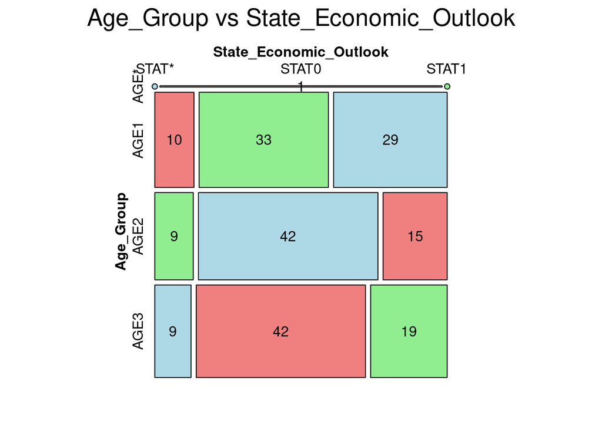

```
## AGE: 1 under 35, 2 35-54, 3 55 and over
## STAT: 0 better, 1 not better than a year ago
```

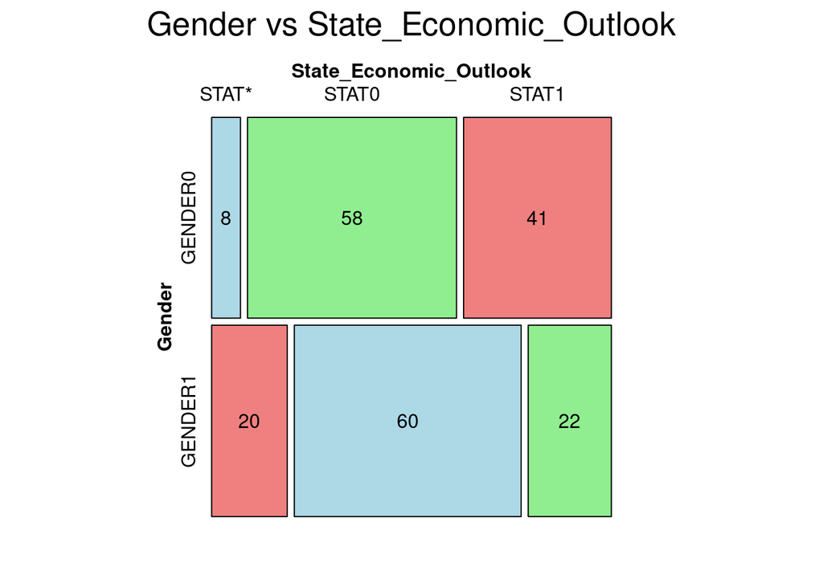

```
## GENDER: 0 male, 1 female
## STAT: 0 better, 1 not better than a year ago
```

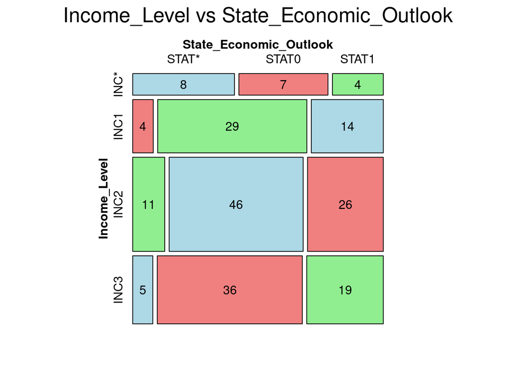

```
## INC: 1 under $20K, 2 20-35$K, 3 over $35K
## STAT: 0 better, 1 not better than a year ago
```

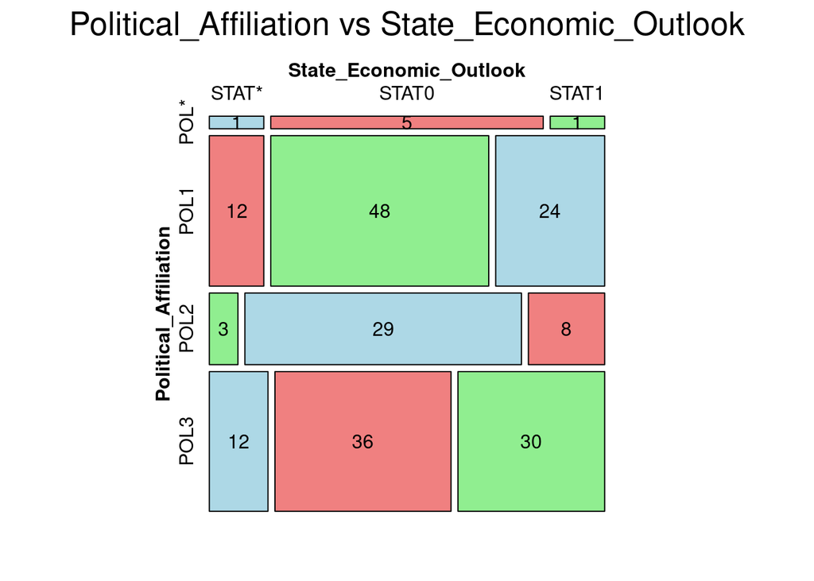

```
## POL: 1 Democrat, 2 Independent, 3 Republican
## STAT: 0 better, 1 not better than a year ago
```

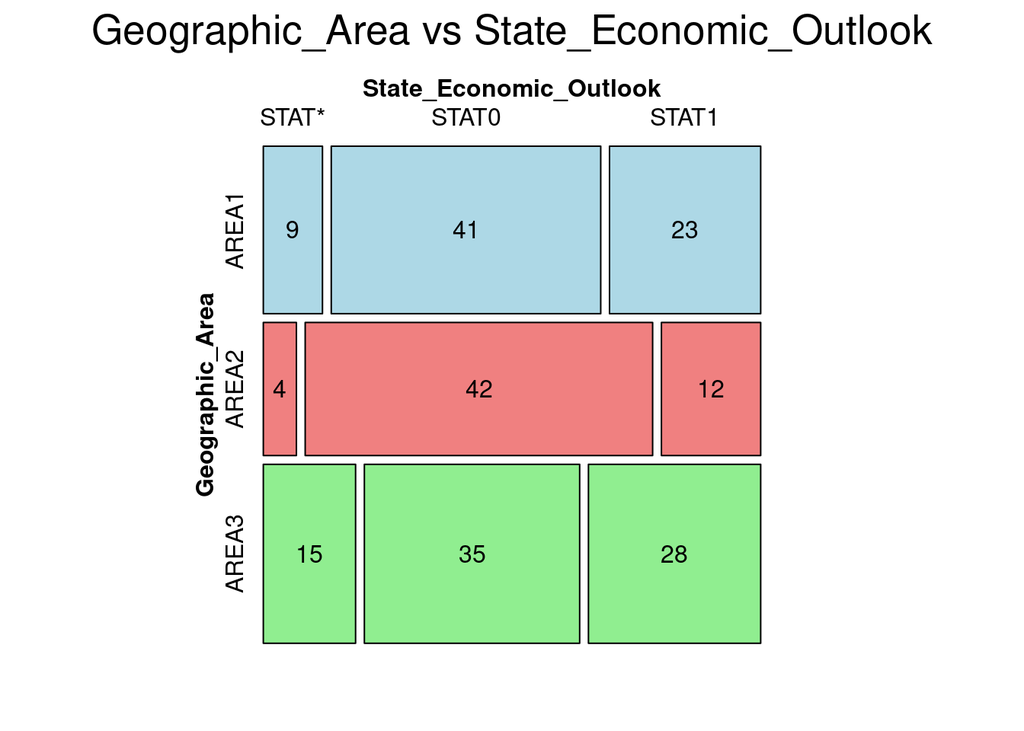

```
## AREA: 1 Western, 2 Northeastern, 3 Southeastern Montana
## STAT: 0 better, 1 not better than a year ago
```

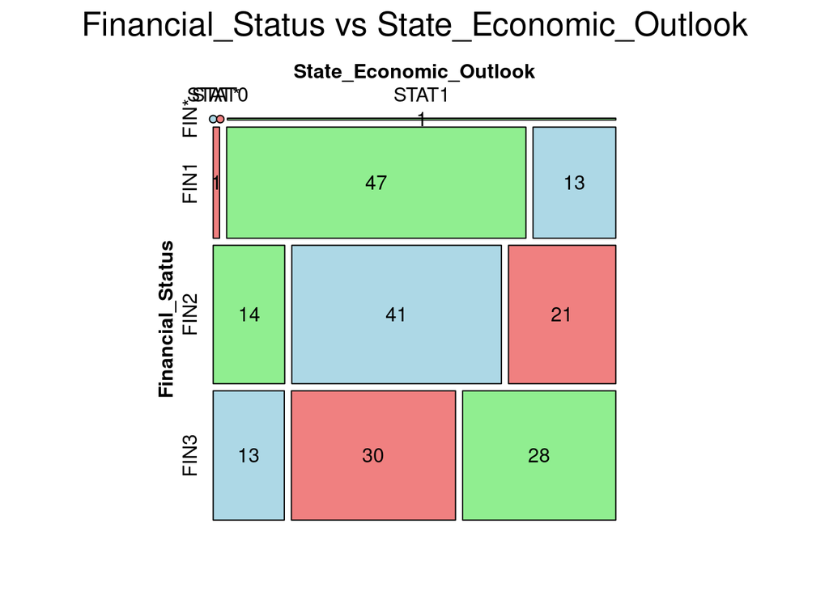

```
## FIN: 1 worse, 2 same, 3 better than a year ago
## STAT: 0 better, 1 not better than a year ago
```

```r
# Get all variable names except STAT
other_vars <- names(polling)[names(polling) != "State_Economic_Outlook"]

# Define variable-specific reference information
var_info <- list(
  "Age_Group" = "AGE: 1 under 35, 2 35-54, 3 55 and over",
  "Gender" = "GENDER: 0 male, 1 female",
  "Income_Level" = "INC: 1 under $20K, 2 20-35$K, 3 over $35K",
  "Political_Affiliation" = "POL: 1 Democrat, 2 Independent, 3 Republican",
  "Geographic_Area" = "AREA: 1 Western, 2 Northeastern, 3 Southeastern Montana",
  "Financial_Status" = "FIN: 1 worse, 2 same, 3 better than a year ago"
)
# Loops through all columns and compares to STAT
for (var in other_vars) {
  # Create mosaic plot with STAT on y-axis (put STAT last in formula)
  mosaic(as.formula(paste("~", var, "+ State_Economic_Outlook")),
         data = polling,
         main = paste(var, "vs State_Economic_Outlook"),
         xlab = var,
         ylab = "State Economic Outlook",
         labeling = labeling_values,
         gp = gpar(fill =
                     c("lightblue", "lightcoral", "lightgreen")))

  # Print variable-specific reference information
  if (var %in% names(var_info)) {
    cat(var_info[[var]], "\n")
  }

  # Print STAT reference
  cat("STAT: 0 better, 1 not better than a year ago\n\n")
}
```

## Prepare dataframe for item set and association rules analysis.

The following replaces missing values with ‘NA’, cleans the rows with empty values, does a calculation to show data loss after cleaning, and proceeds to change character/text to a factor type to allow apriori algorithm calculations.

There was approximately a 78% data retention after cleaning which was found to most likely be sufficient for association analysis and subsequently have better data quality and associations.

```r
# Replace values ending with asterisk with NA
for (col in names(polling)) {

  # Find values that end with asterisk
  asterisk_rows <- grepl("\\*$", polling[[col]])
  asterisk_rows[is.na(asterisk_rows)] <- FALSE  # Handle NAs separately
  polling[[col]][asterisk_rows] <- NA
}

# Row count pre cleaning
row_count <- nrow(polling)
cat("Row count before cleaning:", row_count)
```

```
## Row count before cleaning: 209
```

```r
# Clean any NA or missing values if needed.
polling <- polling[complete.cases(polling), ]

# Row count after cleaning
row_count_na_removed <- nrow(polling)
cat("Row count after cleaning: ", row_count_na_removed)
```

```
## Row count after cleaning:  163
```

```r
# Data loss calculation
data_loss <- (row_count_na_removed / row_count)
cat("Data retained after cleaning", data_loss)
```

```
## Data retained after cleaning 0.7799043
```

```r
# Quick factor conversion for association rules
data_factors <- data.frame(lapply(polling, as.factor))

# Show results of factor conversion and cleaning NA values.
head(data_factors, 10)
```

```
##    Age_Group  Gender Income_Level Political_Affiliation Geographic_Area
## 1       AGE3 GENDER0         INC2                  POL2           AREA1
## 2       AGE2 GENDER0         INC3                  POL3           AREA1
## 3       AGE3 GENDER1         INC2                  POL1           AREA1
## 4       AGE3 GENDER1         INC1                  POL3           AREA3
## 5       AGE1 GENDER0         INC1                  POL3           AREA2
## 6       AGE3 GENDER1         INC1                  POL3           AREA2
## 7       AGE2 GENDER0         INC2                  POL1           AREA3
## 8       AGE3 GENDER0         INC3                  POL3           AREA3
## 9       AGE3 GENDER0         INC3                  POL1           AREA3
## 10      AGE3 GENDER1         INC2                  POL1           AREA3
##    Financial_Status State_Economic_Outlook
## 1              FIN2                  STAT1
## 2              FIN3                  STAT1
## 3              FIN1                  STAT0
## 4              FIN1                  STAT1
## 5              FIN1                  STAT0
## 6              FIN2                  STAT0
## 7              FIN3                  STAT0
## 8              FIN3                  STAT1
## 9              FIN1                  STAT1
## 10             FIN2                  STAT1
```

## Create itemsets using arules package.

Support = 0.10 | Confidence = 0.70 minlen = 2 | maxlen = 10

```r
# Convert to transactions object for arules analysis
transactions <- as(data_factors, "transactions")

# Generate frequent itemsets
cat("=== GENERATING FREQUENT ITEMSETS ===\n")
```

```
## === GENERATING FREQUENT ITEMSETS ===
```

```r
frequent_itemsets <- apriori(transactions,
                             parameter = list(support = 0.10,
                                              confidence = 0.70,
                                              minlen = 2,
                                              maxlen = 10,
                                              target = "frequent itemsets"))
```

```
## Apriori
##
## Parameter specification:
##  confidence minval smax arem  aval originalSupport maxtime support minlen
##          NA    0.1    1 none FALSE            TRUE       5     0.1      2
##  maxlen            target  ext
##      10 frequent itemsets TRUE
##
## Algorithmic control:
##  filter tree heap memopt load sort verbose
##     0.1 TRUE TRUE  FALSE TRUE    2    TRUE
##
## Absolute minimum support count: 16
##
## set item appearances ...[0 item(s)] done [0.00s].
## set transactions ...[19 item(s), 163 transaction(s)] done [0.00s].
## sorting and recoding items ... [19 item(s)] done [0.00s].
## creating transaction tree ... done [0.00s].
## checking subsets of size 1 2 3 4 done [0.00s].
## sorting transactions ... done [0.00s].
## writing ... [150 set(s)] done [0.00s].
## creating S4 object  ... done [0.00s].
```

```r
cat("Frequent Itemsets Summary:\n")
```

```
## Frequent Itemsets Summary:
```

```r
summary(frequent_itemsets)
```

```
## set of 150 itemsets
##
## most frequent items:
## State_Economic_Outlook=STAT0               Gender=GENDER0
##                           49                           31
##               Gender=GENDER1   Political_Affiliation=POL1
##                           27                           23
##            Income_Level=INC2                      (Other)
##                           22                          187
##
## element (itemset/transaction) length distribution:sizes
##   2   3
## 111  39
##
##    Min. 1st Qu.  Median    Mean 3rd Qu.    Max.
##    2.00    2.00    2.00    2.26    3.00    3.00
##
## summary of quality measures:
##     support           count
##  Min.   :0.1043   Min.   :17.0
##  1st Qu.:0.1166   1st Qu.:19.0
##  Median :0.1350   Median :22.0
##  Mean   :0.1491   Mean   :24.3
##  3rd Qu.:0.1656   3rd Qu.:27.0
##  Max.   :0.3313   Max.   :54.0
##
## includes transaction ID lists: FALSE
##
## mining info:
##          data ntransactions support confidence
##  transactions           163     0.1          1
##                                                                                                                                    call
##  apriori(data = transactions, parameter = list(support = 0.1, confidence = 0.7, minlen = 2, maxlen = 10, target = "frequent itemsets"))
```

```r
cat("\n")
```

```r
# Inspect frequent itemsets (sorted by support)
cat("=== FREQUENT ITEMSETS (sorted by support) ===\n")
```

```
## === FREQUENT ITEMSETS (sorted by support) ===
```

```r
cat("\n")
```

```r
# Sort the itemsets by support for easy viewing.
frequent_itemsets_sorted <- sort(frequent_itemsets,
                                 by = "support", decreasing = TRUE)

# Package conflict; had to reload the arules package.
arules::inspect(frequent_itemsets_sorted)
```

```
##       items                            support count
## [1]   {Gender=GENDER0,
##        State_Economic_Outlook=STAT0} 0.3312883    54
## [2]   {Gender=GENDER1,
##        State_Economic_Outlook=STAT0} 0.3190184    52
## [3]   {Political_Affiliation=POL1,
##        State_Economic_Outlook=STAT0} 0.2822086    46
## [4]   {Income_Level=INC2,
##        State_Economic_Outlook=STAT0} 0.2760736    45
## [5]   {Financial_Status=FIN1,
##        State_Economic_Outlook=STAT0} 0.2576687    42
## [6]   {Geographic_Area=AREA2,
##        State_Economic_Outlook=STAT0} 0.2453988    40
## [7]   {Age_Group=AGE2,
##        State_Economic_Outlook=STAT0} 0.2392638    39
## [8]   {Gender=GENDER0,
##        Political_Affiliation=POL3}   0.2392638    39
## [9]   {Gender=GENDER0,
##        Income_Level=INC3}            0.2331288    38
## [10]  {Age_Group=AGE3,
##        State_Economic_Outlook=STAT0} 0.2269939    37
## [11]  {Gender=GENDER0,
##        State_Economic_Outlook=STAT1} 0.2269939    37
## [12]  {Gender=GENDER0,
##        Income_Level=INC2}            0.2269939    37
## [13]  {Financial_Status=FIN2,
##        State_Economic_Outlook=STAT0} 0.2208589    36
## [14]  {Age_Group=AGE2,
##        Gender=GENDER0}               0.2208589    36
## [15]  {Geographic_Area=AREA1,
##        State_Economic_Outlook=STAT0} 0.2208589    36
## [16]  {Income_Level=INC3,
##        State_Economic_Outlook=STAT0} 0.2147239    35
## [17]  {Gender=GENDER1,
##        Political_Affiliation=POL1}   0.2147239    35
## [18]  {Political_Affiliation=POL3,
##        State_Economic_Outlook=STAT0} 0.2085890    34
## [19]  {Gender=GENDER0,
##        Geographic_Area=AREA3}        0.2024540    33
## [20]  {Gender=GENDER1,
```

[output cut: 285 more lines]

```
## [146] {Age_Group=AGE2,
##        Gender=GENDER1,
##        State_Economic_Outlook=STAT0} 0.1042945    17
## [147] {Age_Group=AGE3,
##        Gender=GENDER1,
##        State_Economic_Outlook=STAT0} 0.1042945    17
## [148] {Geographic_Area=AREA1,
##        Financial_Status=FIN1,
##        State_Economic_Outlook=STAT0} 0.1042945    17
## [149] {Age_Group=AGE1,
##        Gender=GENDER1,
##        Financial_Status=FIN3}        0.1042945    17
## [150] {Gender=GENDER0,
##        Geographic_Area=AREA3,
##        State_Economic_Outlook=STAT0} 0.1042945    17
```

## Create interactive inspection

```r
# Create interactive inspection
cat("=== CREATING INTERACTIVE HTML EXPORT ===\n")
```

```
## === CREATING INTERACTIVE HTML EXPORT ===
```

```r
itemsets_interactive <- inspectDT(frequent_itemsets_sorted)

# Display in RStudio viewer/browser
itemsets_interactive
```

|  | items | support | count |
| --- | --- | --- | --- |
| [111] | {Gender=GENDER0,State_Economic_Outlook=STAT0} | 0.3312883435582822 | 54 |
| [110] | {Gender=GENDER1,State_Economic_Outlook=STAT0} | 0.3190184049079755 | 52 |
| [106] | {Political_Affiliation=POL1,State_Economic_Outlook=STAT0} | 0.2822085889570552 | 46 |
| [109] | {Income_Level=INC2,State_Economic_Outlook=STAT0} | 0.2760736196319019 | 45 |
| [79] | {Financial_Status=FIN1,State_Economic_Outlook=STAT0} | 0.2576687116564417 | 42 |
| [19] | {Geographic_Area=AREA2,State_Economic_Outlook=STAT0} | 0.245398773006135 | 40 |
| [46] | {Age_Group=AGE2,State_Economic_Outlook=STAT0} | 0.2392638036809816 | 39 |
| [101] | {Gender=GENDER0,Political_Affiliation=POL3} | 0.2392638036809816 | 39 |
| [27] | {Gender=GENDER0,Income_Level=INC3} | 0.2331288343558282 | 38 |
| [55] | {Age_Group=AGE3,State_Economic_Outlook=STAT0} | 0.2269938650306748 | 37 |

[output cut: 140 more lines]

```r
# Export to HTML file
htmlwidgets::saveWidget(itemsets_interactive,
                        file = "item_sets.html",
                        selfcontained = TRUE)
```

## Association rules analysis using apriori an and scatterplots

This chunk has two main loops; one loop creates different association analysis for different support levels to find where the most valuable information is; the other loop uses the optimal support value and loops through confidence levels to find a good match. It prints a scatter plot in each iteration.

```
## Apriori
##
## Parameter specification:
##  confidence minval smax arem  aval originalSupport maxtime support minlen
##         0.6    0.1    1 none FALSE            TRUE       5    0.02      1
##  maxlen target  ext
##      10  rules TRUE
##
## Algorithmic control:
##  filter tree heap memopt load sort verbose
##     0.1 TRUE TRUE  FALSE TRUE    2    TRUE
##
## Absolute minimum support count: 3
##
## set item appearances ...[1 item(s)] done [0.00s].
## set transactions ...[19 item(s), 163 transaction(s)] done [0.00s].
## sorting and recoding items ... [19 item(s)] done [0.00s].
## creating transaction tree ... done [0.00s].
## checking subsets of size 1 2 3 4 5 6 done [0.00s].
## writing ... [396 rule(s)] done [0.00s].
## creating S4 object  ... done [0.00s].
## ## Support = 0.02
##
## Found 127 high-lift rules for support = 0.02
##      lhs                              rhs                               support confidence   coverage     lift count
## [1]  {Political_Affiliation=POL2,
##       Geographic_Area=AREA2}       => {State_Economic_Outlook=STAT0} 0.07361963  1.0000000 0.07361963 1.537736    12
## [2]  {Age_Group=AGE2,
##       Political_Affiliation=POL2}  => {State_Economic_Outlook=STAT0} 0.06748466  0.8461538 0.07975460 1.301161    11
## [3]  {Gender=GENDER1,
##       Political_Affiliation=POL2}  => {State_Economic_Outlook=STAT0} 0.07361963  0.9230769 0.07975460 1.419448    12
## [4]  {Age_Group=AGE2,
##       Income_Level=INC1}           => {State_Economic_Outlook=STAT0} 0.03680982  0.8571429 0.04294479 1.318059     6
## [5]  {Age_Group=AGE2,
##       Geographic_Area=AREA2}       => {State_Economic_Outlook=STAT0} 0.07975460  0.8666667 0.09202454 1.332704    13
## [6]  {Age_Group=AGE3,
##       Geographic_Area=AREA2}       => {State_Economic_Outlook=STAT0} 0.09815951  0.8888889 0.11042945 1.366876    16
## [7]  {Age_Group=AGE2,
##       Financial_Status=FIN1}       => {State_Economic_Outlook=STAT0} 0.08588957  0.8750000 0.09815951 1.345519    14
## [8]  {Age_Group=AGE2,
##       Gender=GENDER1}              => {State_Economic_Outlook=STAT0} 0.10429448  0.9444444 0.11042945 1.452306    17
## [9]  {Gender=GENDER1,
##       Financial_Status=FIN1}       => {State_Economic_Outlook=STAT0} 0.13496933  0.8800000 0.15337423 1.353208    22
## [10] {Political_Affiliation=POL2,
##       Geographic_Area=AREA2,
##       Financial_Status=FIN2}       => {State_Economic_Outlook=STAT0} 0.03680982  1.0000000 0.03680982 1.537736     6
```

```
## To reduce overplotting, jitter is added! Use jitter = 0 to prevent jitter.
```

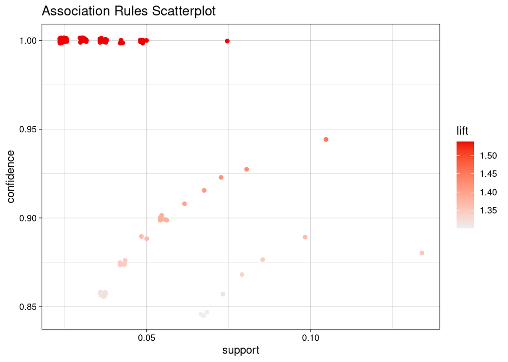

```
## Apriori
##
## Parameter specification:
##  confidence minval smax arem  aval originalSupport maxtime support minlen
##         0.6    0.1    1 none FALSE            TRUE       5    0.04      1
##  maxlen target  ext
##      10  rules TRUE
##
## Algorithmic control:
##  filter tree heap memopt load sort verbose
##     0.1 TRUE TRUE  FALSE TRUE    2    TRUE
##
## Absolute minimum support count: 6
##
## set item appearances ...[1 item(s)] done [0.00s].
## set transactions ...[19 item(s), 163 transaction(s)] done [0.00s].
## sorting and recoding items ... [19 item(s)] done [0.00s].
## creating transaction tree ... done [0.00s].
## checking subsets of size 1 2 3 4 5 done [0.00s].
## writing ... [179 rule(s)] done [0.00s].
## creating S4 object  ... done [0.00s].
## ## Support = 0.04
##
## Found 42 high-lift rules for support = 0.04
##      lhs                              rhs                               support confidence   coverage     lift count
## [1]  {Political_Affiliation=POL2,
##       Geographic_Area=AREA2}       => {State_Economic_Outlook=STAT0} 0.07361963  1.0000000 0.07361963 1.537736    12
## [2]  {Age_Group=AGE2,
##       Political_Affiliation=POL2}  => {State_Economic_Outlook=STAT0} 0.06748466  0.8461538 0.07975460 1.301161    11
## [3]  {Gender=GENDER1,
##       Political_Affiliation=POL2}  => {State_Economic_Outlook=STAT0} 0.07361963  0.9230769 0.07975460 1.419448    12
## [4]  {Age_Group=AGE2,
##       Geographic_Area=AREA2}       => {State_Economic_Outlook=STAT0} 0.07975460  0.8666667 0.09202454 1.332704    13
## [5]  {Age_Group=AGE3,
##       Geographic_Area=AREA2}       => {State_Economic_Outlook=STAT0} 0.09815951  0.8888889 0.11042945 1.366876    16
## [6]  {Age_Group=AGE2,
##       Financial_Status=FIN1}       => {State_Economic_Outlook=STAT0} 0.08588957  0.8750000 0.09815951 1.345519    14
## [7]  {Age_Group=AGE2,
##       Gender=GENDER1}              => {State_Economic_Outlook=STAT0} 0.10429448  0.9444444 0.11042945 1.452306    17
## [8]  {Gender=GENDER1,
##       Financial_Status=FIN1}       => {State_Economic_Outlook=STAT0} 0.13496933  0.8800000 0.15337423 1.353208    22
## [9]  {Income_Level=INC2,
##       Political_Affiliation=POL2,
##       Geographic_Area=AREA2}       => {State_Economic_Outlook=STAT0} 0.04907975  1.0000000 0.04907975 1.537736     8
## [10] {Gender=GENDER0,
##       Political_Affiliation=POL2,
##       Geographic_Area=AREA2}       => {State_Economic_Outlook=STAT0} 0.04294479  1.0000000 0.04294479 1.537736     7
```

```
## To reduce overplotting, jitter is added! Use jitter = 0 to prevent jitter.
```

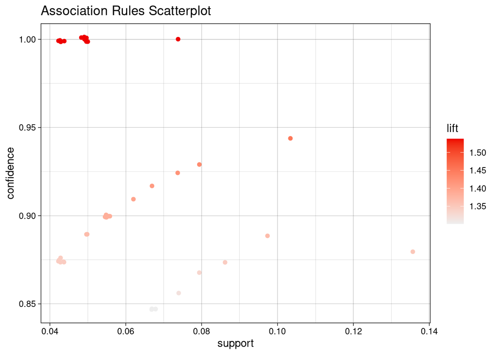

```
## Apriori
##
## Parameter specification:
##  confidence minval smax arem  aval originalSupport maxtime support minlen
##         0.6    0.1    1 none FALSE            TRUE       5    0.06      1
##  maxlen target  ext
##      10  rules TRUE
##
## Algorithmic control:
##  filter tree heap memopt load sort verbose
##     0.1 TRUE TRUE  FALSE TRUE    2    TRUE
##
## Absolute minimum support count: 9
##
## set item appearances ...[1 item(s)] done [0.00s].
## set transactions ...[19 item(s), 163 transaction(s)] done [0.00s].
## sorting and recoding items ... [19 item(s)] done [0.00s].
## creating transaction tree ... done [0.00s].
## checking subsets of size 1 2 3 4 done [0.00s].
## writing ... [95 rule(s)] done [0.00s].
## creating S4 object  ... done [0.00s].
## ## Support = 0.06
##
## Found 15 high-lift rules for support = 0.06
##      lhs                              rhs                               support confidence   coverage     lift count
## [1]  {Political_Affiliation=POL2,
##       Geographic_Area=AREA2}       => {State_Economic_Outlook=STAT0} 0.07361963  1.0000000 0.07361963 1.537736    12
## [2]  {Age_Group=AGE2,
##       Political_Affiliation=POL2}  => {State_Economic_Outlook=STAT0} 0.06748466  0.8461538 0.07975460 1.301161    11
## [3]  {Gender=GENDER1,
##       Political_Affiliation=POL2}  => {State_Economic_Outlook=STAT0} 0.07361963  0.9230769 0.07975460 1.419448    12
## [4]  {Age_Group=AGE2,
##       Geographic_Area=AREA2}       => {State_Economic_Outlook=STAT0} 0.07975460  0.8666667 0.09202454 1.332704    13
## [5]  {Age_Group=AGE3,
##       Geographic_Area=AREA2}       => {State_Economic_Outlook=STAT0} 0.09815951  0.8888889 0.11042945 1.366876    16
## [6]  {Age_Group=AGE2,
##       Financial_Status=FIN1}       => {State_Economic_Outlook=STAT0} 0.08588957  0.8750000 0.09815951 1.345519    14
## [7]  {Age_Group=AGE2,
##       Gender=GENDER1}              => {State_Economic_Outlook=STAT0} 0.10429448  0.9444444 0.11042945 1.452306    17
## [8]  {Gender=GENDER1,
##       Financial_Status=FIN1}       => {State_Economic_Outlook=STAT0} 0.13496933  0.8800000 0.15337423 1.353208    22
## [9]  {Gender=GENDER1,
##       Income_Level=INC1,
##       Political_Affiliation=POL1}  => {State_Economic_Outlook=STAT0} 0.06748466  0.8461538 0.07975460 1.301161    11
## [10] {Gender=GENDER0,
##       Income_Level=INC2,
##       Geographic_Area=AREA2}       => {State_Economic_Outlook=STAT0} 0.06134969  0.9090909 0.06748466 1.397942    10
```

```
## To reduce overplotting, jitter is added! Use jitter = 0 to prevent jitter.
```

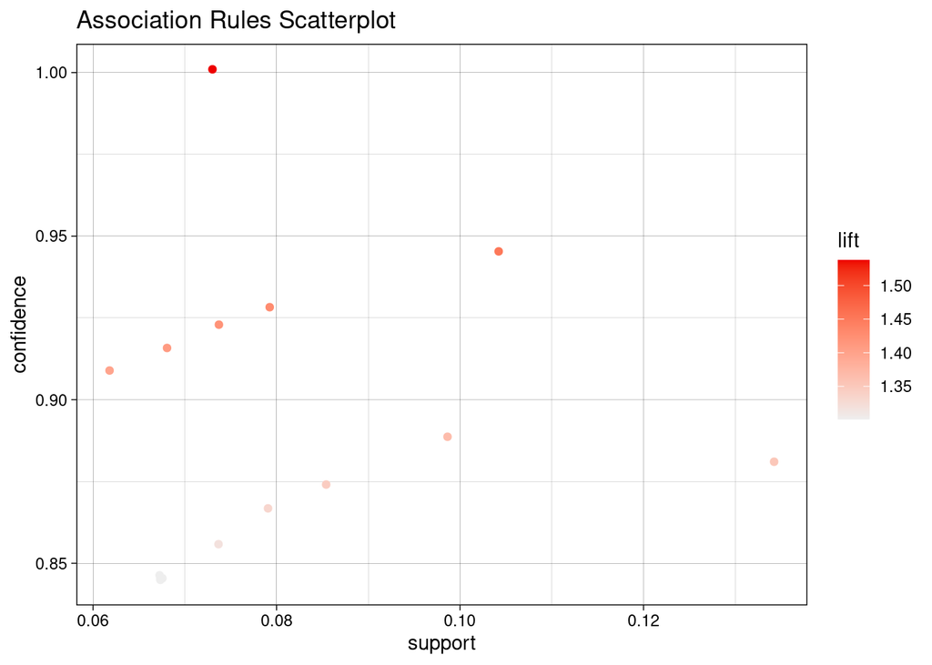

```
## Apriori
##
## Parameter specification:
##  confidence minval smax arem  aval originalSupport maxtime support minlen
##         0.6    0.1    1 none FALSE            TRUE       5    0.08      1
##  maxlen target  ext
##      10  rules TRUE
##
## Algorithmic control:
##  filter tree heap memopt load sort verbose
##     0.1 TRUE TRUE  FALSE TRUE    2    TRUE
##
## Absolute minimum support count: 13
##
## set item appearances ...[1 item(s)] done [0.00s].
## set transactions ...[19 item(s), 163 transaction(s)] done [0.00s].
## sorting and recoding items ... [19 item(s)] done [0.00s].
## creating transaction tree ... done [0.00s].
## checking subsets of size 1 2 3 4 done [0.00s].
## writing ... [61 rule(s)] done [0.00s].
## creating S4 object  ... done [0.00s].
## ## Support = 0.08
##
## Found 4 high-lift rules for support = 0.08
##     lhs                        rhs                               support confidence   coverage     lift count
## [1] {Age_Group=AGE3,
##      Geographic_Area=AREA2} => {State_Economic_Outlook=STAT0} 0.09815951  0.8888889 0.11042945 1.366876    16
## [2] {Age_Group=AGE2,
##      Financial_Status=FIN1} => {State_Economic_Outlook=STAT0} 0.08588957  0.8750000 0.09815951 1.345519    14
## [3] {Age_Group=AGE2,
##      Gender=GENDER1}        => {State_Economic_Outlook=STAT0} 0.10429448  0.9444444 0.11042945 1.452306    17
## [4] {Gender=GENDER1,
##      Financial_Status=FIN1} => {State_Economic_Outlook=STAT0} 0.13496933  0.8800000 0.15337423 1.353208    22
```

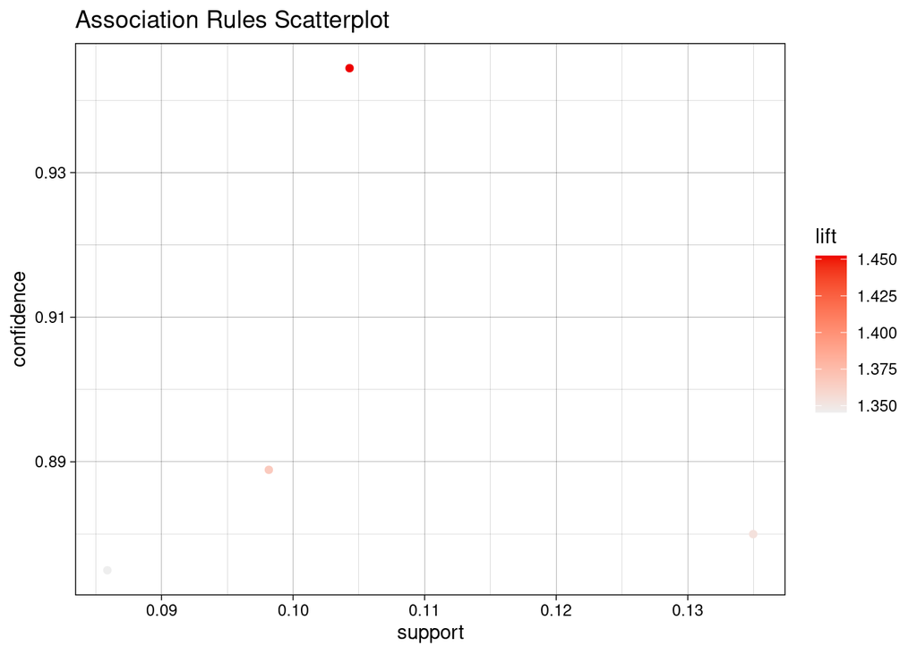

```r
support_range <- seq(0.02, 0.08, by = 0.02)

for (supp in support_range) {
  # Create association rules with STAT as consequent
  rules <- apriori(transactions,
                   parameter = list(
                     supp = supp,      # Experiment with these values
                     conf = 0.60,      # Experiment with these values
                     minlen = 1,
                     maxlen = 10,
                     target = "rules"
                   ),
                   appearance = list(
                     rhs = c("State_Economic_Outlook=STAT0"),
                     default = "lhs"
                   ))

  # Filter rules with lift > 1.3
  high_lift_rules <- subset(rules, lift > 1.3)

  if (length(high_lift_rules) > 0) {
    cat("## Support =", supp, "\n\n")
    cat("Found", length(high_lift_rules),
        "high-lift rules for support =", supp, "\n")

    arules::inspect(head(high_lift_rules, 10))

    # Create scatterplot with support x-axis, confidence y-axis, colored by lift
    print(plot(high_lift_rules,
      method = "scatterplot",
      measure = c("support", "confidence"),
      shading = "lift",
      main = "Association Rules Scatterplot",
    ))
  } else {
    cat("No rules with lift > 1.3 found for support =", supp, "\n")
  }
}
```

```
## Apriori
##
## Parameter specification:
##  confidence minval smax arem  aval originalSupport maxtime support minlen
##         0.9    0.1    1 none FALSE            TRUE       5    0.02      1
##  maxlen target  ext
##      10  rules TRUE
##
## Algorithmic control:
##  filter tree heap memopt load sort verbose
##     0.1 TRUE TRUE  FALSE TRUE    2    TRUE
##
## Absolute minimum support count: 3
##
## set item appearances ...[1 item(s)] done [0.00s].
## set transactions ...[19 item(s), 163 transaction(s)] done [0.00s].
## sorting and recoding items ... [19 item(s)] done [0.00s].
## creating transaction tree ... done [0.00s].
## checking subsets of size 1 2 3 4 5 6 done [0.00s].
## writing ... [99 rule(s)] done [0.00s].
## creating S4 object  ... done [0.00s].
## ## Confidence = 0.9
##
## Found 99 high-lift rules for confidence = 0.9
##      lhs                              rhs                               support confidence   coverage     lift count
## [1]  {Political_Affiliation=POL2,
##       Geographic_Area=AREA2}       => {State_Economic_Outlook=STAT0} 0.07361963  1.0000000 0.07361963 1.537736    12
## [2]  {Gender=GENDER1,
##       Political_Affiliation=POL2}  => {State_Economic_Outlook=STAT0} 0.07361963  0.9230769 0.07975460 1.419448    12
## [3]  {Age_Group=AGE2,
##       Gender=GENDER1}              => {State_Economic_Outlook=STAT0} 0.10429448  0.9444444 0.11042945 1.452306    17
## [4]  {Political_Affiliation=POL2,
##       Geographic_Area=AREA2,
##       Financial_Status=FIN2}       => {State_Economic_Outlook=STAT0} 0.03680982  1.0000000 0.03680982 1.537736     6
## [5]  {Age_Group=AGE2,
##       Political_Affiliation=POL2,
##       Geographic_Area=AREA2}       => {State_Economic_Outlook=STAT0} 0.03067485  1.0000000 0.03067485 1.537736     5
## [6]  {Age_Group=AGE3,
##       Political_Affiliation=POL2,
##       Geographic_Area=AREA2}       => {State_Economic_Outlook=STAT0} 0.03067485  1.0000000 0.03067485 1.537736     5
## [7]  {Political_Affiliation=POL2,
##       Geographic_Area=AREA2,
##       Financial_Status=FIN1}       => {State_Economic_Outlook=STAT0} 0.02453988  1.0000000 0.02453988 1.537736     4
## [8]  {Income_Level=INC2,
##       Political_Affiliation=POL2,
##       Geographic_Area=AREA2}       => {State_Economic_Outlook=STAT0} 0.04907975  1.0000000 0.04907975 1.537736     8
## [9]  {Gender=GENDER1,
##       Political_Affiliation=POL2,
##       Geographic_Area=AREA2}       => {State_Economic_Outlook=STAT0} 0.03067485  1.0000000 0.03067485 1.537736     5
## [10] {Gender=GENDER0,
##       Political_Affiliation=POL2,
##       Geographic_Area=AREA2}       => {State_Economic_Outlook=STAT0} 0.04294479  1.0000000 0.04294479 1.537736     7
```

```
## To reduce overplotting, jitter is added! Use jitter = 0 to prevent jitter.
```

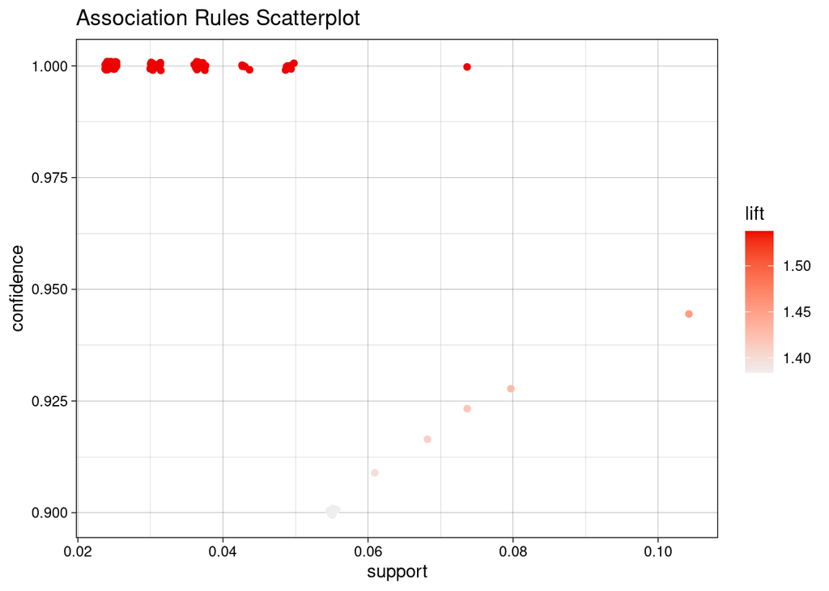

```
## Apriori
##
## Parameter specification:
##  confidence minval smax arem  aval originalSupport maxtime support minlen
##         0.8    0.1    1 none FALSE            TRUE       5    0.02      1
##  maxlen target  ext
##      10  rules TRUE
##
## Algorithmic control:
##  filter tree heap memopt load sort verbose
##     0.1 TRUE TRUE  FALSE TRUE    2    TRUE
##
## Absolute minimum support count: 3
##
## set item appearances ...[1 item(s)] done [0.00s].
## set transactions ...[19 item(s), 163 transaction(s)] done [0.00s].
## sorting and recoding items ... [19 item(s)] done [0.00s].
## creating transaction tree ... done [0.00s].
## checking subsets of size 1 2 3 4 5 6 done [0.00s].
## writing ... [216 rule(s)] done [0.00s].
## creating S4 object  ... done [0.00s].
## ## Confidence = 0.8
##
## Found 127 high-lift rules for confidence = 0.8
##      lhs                              rhs                               support confidence   coverage     lift count
## [1]  {Political_Affiliation=POL2,
##       Geographic_Area=AREA2}       => {State_Economic_Outlook=STAT0} 0.07361963  1.0000000 0.07361963 1.537736    12
## [2]  {Age_Group=AGE2,
##       Political_Affiliation=POL2}  => {State_Economic_Outlook=STAT0} 0.06748466  0.8461538 0.07975460 1.301161    11
## [3]  {Gender=GENDER1,
##       Political_Affiliation=POL2}  => {State_Economic_Outlook=STAT0} 0.07361963  0.9230769 0.07975460 1.419448    12
## [4]  {Age_Group=AGE2,
##       Income_Level=INC1}           => {State_Economic_Outlook=STAT0} 0.03680982  0.8571429 0.04294479 1.318059     6
## [5]  {Age_Group=AGE2,
##       Geographic_Area=AREA2}       => {State_Economic_Outlook=STAT0} 0.07975460  0.8666667 0.09202454 1.332704    13
## [6]  {Age_Group=AGE3,
##       Geographic_Area=AREA2}       => {State_Economic_Outlook=STAT0} 0.09815951  0.8888889 0.11042945 1.366876    16
## [7]  {Age_Group=AGE2,
##       Financial_Status=FIN1}       => {State_Economic_Outlook=STAT0} 0.08588957  0.8750000 0.09815951 1.345519    14
## [8]  {Age_Group=AGE2,
##       Gender=GENDER1}              => {State_Economic_Outlook=STAT0} 0.10429448  0.9444444 0.11042945 1.452306    17
## [9]  {Gender=GENDER1,
##       Financial_Status=FIN1}       => {State_Economic_Outlook=STAT0} 0.13496933  0.8800000 0.15337423 1.353208    22
## [10] {Political_Affiliation=POL2,
##       Geographic_Area=AREA2,
##       Financial_Status=FIN2}       => {State_Economic_Outlook=STAT0} 0.03680982  1.0000000 0.03680982 1.537736     6
```

```
## To reduce overplotting, jitter is added! Use jitter = 0 to prevent jitter.
```

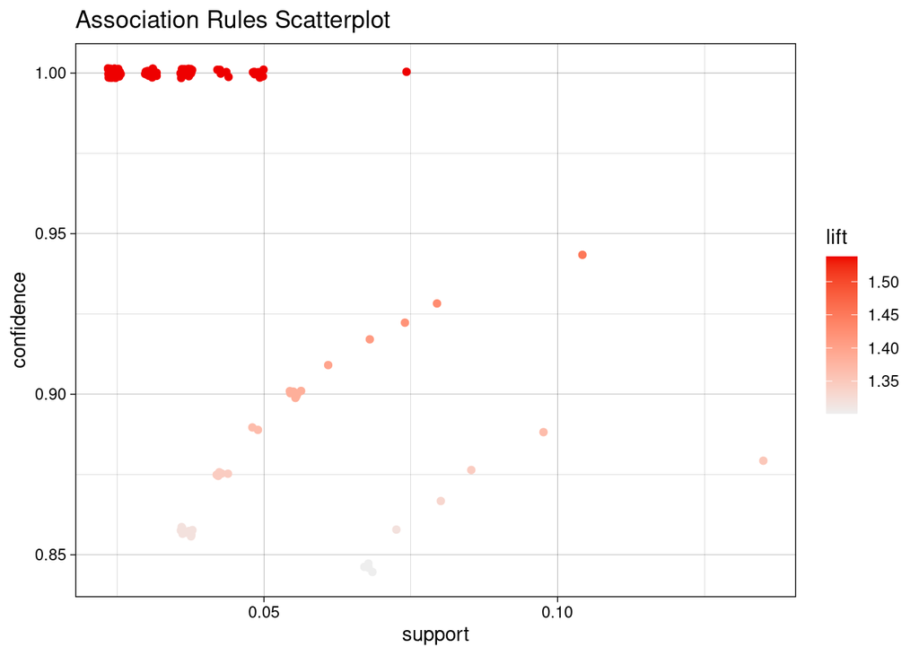

```
## Apriori
##
## Parameter specification:
##  confidence minval smax arem  aval originalSupport maxtime support minlen
##         0.7    0.1    1 none FALSE            TRUE       5    0.02      1
##  maxlen target  ext
##      10  rules TRUE
##
## Algorithmic control:
##  filter tree heap memopt load sort verbose
##     0.1 TRUE TRUE  FALSE TRUE    2    TRUE
##
## Absolute minimum support count: 3
##
## set item appearances ...[1 item(s)] done [0.00s].
## set transactions ...[19 item(s), 163 transaction(s)] done [0.00s].
## sorting and recoding items ... [19 item(s)] done [0.00s].
## creating transaction tree ... done [0.00s].
## checking subsets of size 1 2 3 4 5 6 done [0.00s].
## writing ... [301 rule(s)] done [0.00s].
## creating S4 object  ... done [0.00s].
## ## Confidence = 0.7
##
## Found 127 high-lift rules for confidence = 0.7
##      lhs                              rhs                               support confidence   coverage     lift count
## [1]  {Political_Affiliation=POL2,
##       Geographic_Area=AREA2}       => {State_Economic_Outlook=STAT0} 0.07361963  1.0000000 0.07361963 1.537736    12
## [2]  {Age_Group=AGE2,
##       Political_Affiliation=POL2}  => {State_Economic_Outlook=STAT0} 0.06748466  0.8461538 0.07975460 1.301161    11
## [3]  {Gender=GENDER1,
##       Political_Affiliation=POL2}  => {State_Economic_Outlook=STAT0} 0.07361963  0.9230769 0.07975460 1.419448    12
## [4]  {Age_Group=AGE2,
##       Income_Level=INC1}           => {State_Economic_Outlook=STAT0} 0.03680982  0.8571429 0.04294479 1.318059     6
## [5]  {Age_Group=AGE2,
##       Geographic_Area=AREA2}       => {State_Economic_Outlook=STAT0} 0.07975460  0.8666667 0.09202454 1.332704    13
## [6]  {Age_Group=AGE3,
##       Geographic_Area=AREA2}       => {State_Economic_Outlook=STAT0} 0.09815951  0.8888889 0.11042945 1.366876    16
## [7]  {Age_Group=AGE2,
##       Financial_Status=FIN1}       => {State_Economic_Outlook=STAT0} 0.08588957  0.8750000 0.09815951 1.345519    14
## [8]  {Age_Group=AGE2,
##       Gender=GENDER1}              => {State_Economic_Outlook=STAT0} 0.10429448  0.9444444 0.11042945 1.452306    17
## [9]  {Gender=GENDER1,
##       Financial_Status=FIN1}       => {State_Economic_Outlook=STAT0} 0.13496933  0.8800000 0.15337423 1.353208    22
## [10] {Political_Affiliation=POL2,
##       Geographic_Area=AREA2,
##       Financial_Status=FIN2}       => {State_Economic_Outlook=STAT0} 0.03680982  1.0000000 0.03680982 1.537736     6
```

```
## To reduce overplotting, jitter is added! Use jitter = 0 to prevent jitter.
```

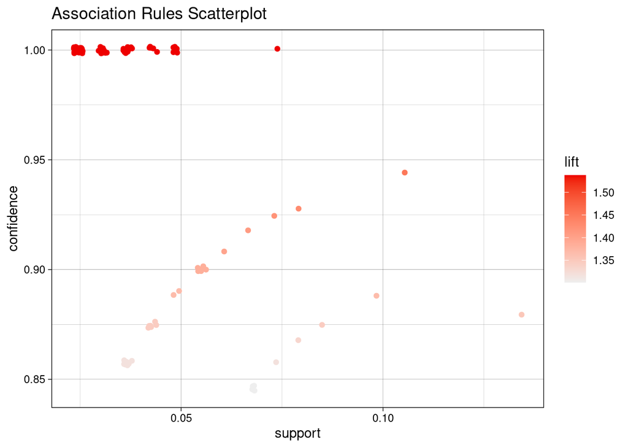

```
## Apriori
##
## Parameter specification:
##  confidence minval smax arem  aval originalSupport maxtime support minlen
##         0.6    0.1    1 none FALSE            TRUE       5    0.02      1
##  maxlen target  ext
##      10  rules TRUE
##
## Algorithmic control:
##  filter tree heap memopt load sort verbose
##     0.1 TRUE TRUE  FALSE TRUE    2    TRUE
##
## Absolute minimum support count: 3
##
## set item appearances ...[1 item(s)] done [0.00s].
## set transactions ...[19 item(s), 163 transaction(s)] done [0.00s].
## sorting and recoding items ... [19 item(s)] done [0.00s].
## creating transaction tree ... done [0.00s].
## checking subsets of size 1 2 3 4 5 6 done [0.00s].
## writing ... [396 rule(s)] done [0.00s].
## creating S4 object  ... done [0.00s].
## ## Confidence = 0.6
##
## Found 127 high-lift rules for confidence = 0.6
##      lhs                              rhs                               support confidence   coverage     lift count
## [1]  {Political_Affiliation=POL2,
##       Geographic_Area=AREA2}       => {State_Economic_Outlook=STAT0} 0.07361963  1.0000000 0.07361963 1.537736    12
## [2]  {Age_Group=AGE2,
##       Political_Affiliation=POL2}  => {State_Economic_Outlook=STAT0} 0.06748466  0.8461538 0.07975460 1.301161    11
## [3]  {Gender=GENDER1,
##       Political_Affiliation=POL2}  => {State_Economic_Outlook=STAT0} 0.07361963  0.9230769 0.07975460 1.419448    12
## [4]  {Age_Group=AGE2,
##       Income_Level=INC1}           => {State_Economic_Outlook=STAT0} 0.03680982  0.8571429 0.04294479 1.318059     6
## [5]  {Age_Group=AGE2,
##       Geographic_Area=AREA2}       => {State_Economic_Outlook=STAT0} 0.07975460  0.8666667 0.09202454 1.332704    13
## [6]  {Age_Group=AGE3,
##       Geographic_Area=AREA2}       => {State_Economic_Outlook=STAT0} 0.09815951  0.8888889 0.11042945 1.366876    16
## [7]  {Age_Group=AGE2,
##       Financial_Status=FIN1}       => {State_Economic_Outlook=STAT0} 0.08588957  0.8750000 0.09815951 1.345519    14
## [8]  {Age_Group=AGE2,
##       Gender=GENDER1}              => {State_Economic_Outlook=STAT0} 0.10429448  0.9444444 0.11042945 1.452306    17
## [9]  {Gender=GENDER1,
##       Financial_Status=FIN1}       => {State_Economic_Outlook=STAT0} 0.13496933  0.8800000 0.15337423 1.353208    22
## [10] {Political_Affiliation=POL2,
##       Geographic_Area=AREA2,
##       Financial_Status=FIN2}       => {State_Economic_Outlook=STAT0} 0.03680982  1.0000000 0.03680982 1.537736     6
```

```
## To reduce overplotting, jitter is added! Use jitter = 0 to prevent jitter.
```

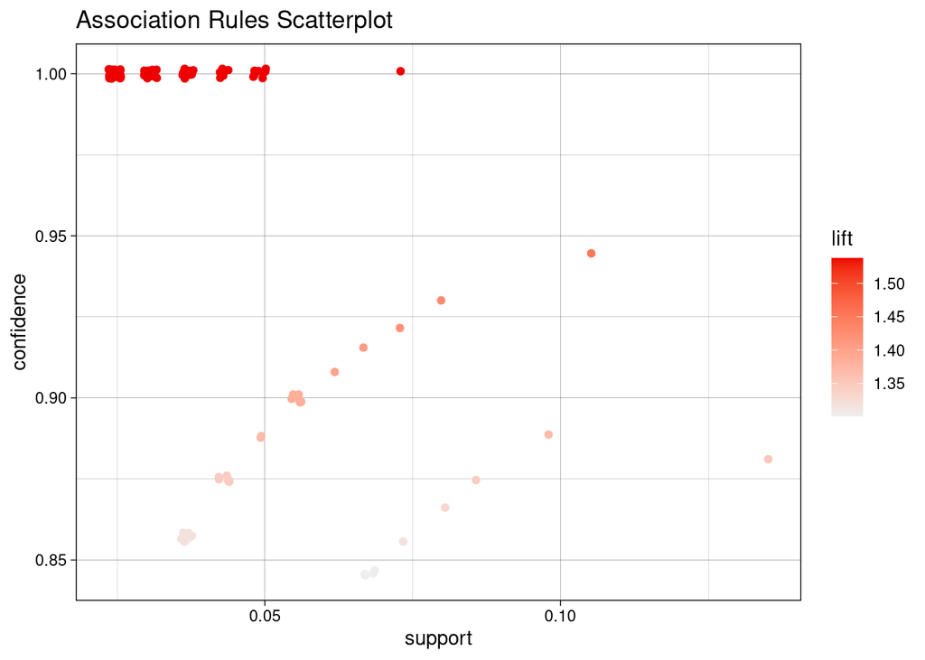

```
## Apriori
##
## Parameter specification:
##  confidence minval smax arem  aval originalSupport maxtime support minlen
##         0.5    0.1    1 none FALSE            TRUE       5    0.02      1
##  maxlen target  ext
##      10  rules TRUE
##
## Algorithmic control:
##  filter tree heap memopt load sort verbose
##     0.1 TRUE TRUE  FALSE TRUE    2    TRUE
##
## Absolute minimum support count: 3
##
## set item appearances ...[1 item(s)] done [0.00s].
## set transactions ...[19 item(s), 163 transaction(s)] done [0.00s].
## sorting and recoding items ... [19 item(s)] done [0.00s].
## creating transaction tree ... done [0.00s].
## checking subsets of size 1 2 3 4 5 6 done [0.00s].
## writing ... [501 rule(s)] done [0.00s].
## creating S4 object  ... done [0.00s].
## ## Confidence = 0.5
##
## Found 127 high-lift rules for confidence = 0.5
##      lhs                              rhs                               support confidence   coverage     lift count
## [1]  {Political_Affiliation=POL2,
##       Geographic_Area=AREA2}       => {State_Economic_Outlook=STAT0} 0.07361963  1.0000000 0.07361963 1.537736    12
## [2]  {Age_Group=AGE2,
##       Political_Affiliation=POL2}  => {State_Economic_Outlook=STAT0} 0.06748466  0.8461538 0.07975460 1.301161    11
## [3]  {Gender=GENDER1,
##       Political_Affiliation=POL2}  => {State_Economic_Outlook=STAT0} 0.07361963  0.9230769 0.07975460 1.419448    12
## [4]  {Age_Group=AGE2,
##       Income_Level=INC1}           => {State_Economic_Outlook=STAT0} 0.03680982  0.8571429 0.04294479 1.318059     6
## [5]  {Age_Group=AGE2,
##       Geographic_Area=AREA2}       => {State_Economic_Outlook=STAT0} 0.07975460  0.8666667 0.09202454 1.332704    13
## [6]  {Age_Group=AGE3,
##       Geographic_Area=AREA2}       => {State_Economic_Outlook=STAT0} 0.09815951  0.8888889 0.11042945 1.366876    16
## [7]  {Age_Group=AGE2,
##       Financial_Status=FIN1}       => {State_Economic_Outlook=STAT0} 0.08588957  0.8750000 0.09815951 1.345519    14
## [8]  {Age_Group=AGE2,
##       Gender=GENDER1}              => {State_Economic_Outlook=STAT0} 0.10429448  0.9444444 0.11042945 1.452306    17
## [9]  {Gender=GENDER1,
##       Financial_Status=FIN1}       => {State_Economic_Outlook=STAT0} 0.13496933  0.8800000 0.15337423 1.353208    22
## [10] {Political_Affiliation=POL2,
##       Geographic_Area=AREA2,
##       Financial_Status=FIN2}       => {State_Economic_Outlook=STAT0} 0.03680982  1.0000000 0.03680982 1.537736     6
```

```
## To reduce overplotting, jitter is added! Use jitter = 0 to prevent jitter.
```

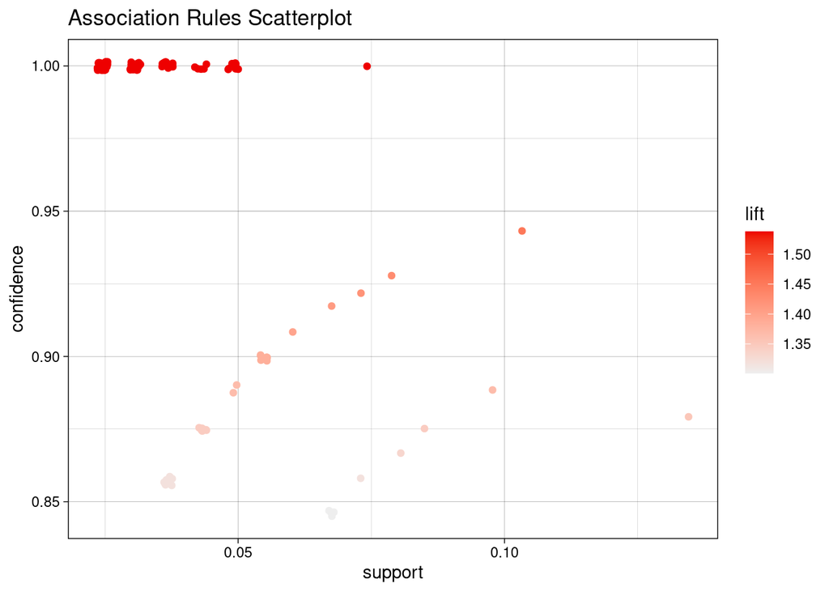

```r
confidence_range <- seq(0.9, 0.5, by = -0.1)

for (conf in confidence_range) {
  # Create association rules with STAT as consequent
  rules <- apriori(transactions,
                   parameter = list(
                     supp = 0.02,      # Experiment with these values
                     conf = conf,      # Experiment with these values
                     minlen = 1,
                     maxlen = 10,
                     target = "rules"
                   ),
                   appearance = list(
                     rhs = c("State_Economic_Outlook=STAT0"),
                     default = "lhs"
                   ))

  # Filter rules with lift > 1.3
  high_lift_rules <- subset(rules, lift > 1.3)

  if (length(high_lift_rules) > 0) {
    cat("## Confidence =", conf, "\n\n")
    cat("Found", length(high_lift_rules),
        "high-lift rules for confidence =", conf, "\n")

    arules::inspect(head(high_lift_rules, 10))

    # Create scatterplot with support x-axis, confidence y-axis, colored by lift
    print(plot(high_lift_rules,
      method = "scatterplot",
      measure = c("support", "confidence"),
      shading = "lift",
      main = "Association Rules Scatterplot",
    ))
  } else {
    cat("No rules with lift > 1.3 found for confidence =", conf, "\n")
  }
}
```

## Interactive Association Rules Inspection and Export

```r
optimal_rules <- apriori(transactions,
                         parameter = list(
                           supp = 0.02,
                           conf = 0.70,
                           minlen = 1,
                           maxlen = 10,
                           target = "rules"
                         ),
                         appearance = list(
                           rhs = c("State_Economic_Outlook=STAT0"),
                           default = "lhs"
                         ))
```

```
## Apriori
##
## Parameter specification:
##  confidence minval smax arem  aval originalSupport maxtime support minlen
##         0.7    0.1    1 none FALSE            TRUE       5    0.02      1
##  maxlen target  ext
##      10  rules TRUE
##
## Algorithmic control:
##  filter tree heap memopt load sort verbose
##     0.1 TRUE TRUE  FALSE TRUE    2    TRUE
##
## Absolute minimum support count: 3
##
## set item appearances ...[1 item(s)] done [0.00s].
## set transactions ...[19 item(s), 163 transaction(s)] done [0.00s].
## sorting and recoding items ... [19 item(s)] done [0.00s].
## creating transaction tree ... done [0.00s].
## checking subsets of size 1 2 3 4 5 6 done [0.00s].
## writing ... [301 rule(s)] done [0.00s].
## creating S4 object  ... done [0.00s].
```

```r
# Filter rules with lift > 1.3
high_lift_rules <- subset(optimal_rules, lift > 1.3)

# Sort rules by lift for better analysis
high_lift_rules_sorted <- sort(high_lift_rules, by = "lift", decreasing = TRUE)

cat("=== CREATING INTERACTIVE RULES INSPECTION ===\n")
```

```
## === CREATING INTERACTIVE RULES INSPECTION ===
```

```r
cat("Total rules found:", length(high_lift_rules_sorted), "\n")
```

```
## Total rules found: 127
```

```r
# Create interactive HTML using inspectDT
rules_interactive <- inspectDT(high_lift_rules_sorted)

# Display in RStudio viewer/browser
rules_interactive
```

|  | LHS | RHS | support | confidence | coverage | lift | count |
| --- | --- | --- | --- | --- | --- | --- | --- |
| [6] | {Political_Affiliation=POL2,Geographic_Area=AREA2} | {State_Economic_Outlook=STAT0} | 0.0736196319018405 | 1 | 0.0736196319018405 | 1.537735849056604 | 12 |
| [57] | {Political_Affiliation=POL2,Geographic_Area=AREA2,Financial_Status=FIN2} | {State_Economic_Outlook=STAT0} | 0.03680981595092025 | 1 | 0.03680981595092025 | 1.537735849056604 | 6 |
| [58] | {Age_Group=AGE2,Political_Affiliation=POL2,Geographic_Area=AREA2} | {State_Economic_Outlook=STAT0} | 0.03067484662576687 | 1 | 0.03067484662576687 | 1.537735849056604 | 5 |
| [59] | {Age_Group=AGE3,Political_Affiliation=POL2,Geographic_Area=AREA2} | {State_Economic_Outlook=STAT0} | 0.03067484662576687 | 1 | 0.03067484662576687 | 1.537735849056604 | 5 |
| [60] | {Political_Affiliation=POL2,Geographic_Area=AREA2,Financial_Status=FIN1} | {State_Economic_Outlook=STAT0} | 0.0245398773006135 | 1 | 0.0245398773006135 | 1.537735849056604 | 4 |
| [61] | {Income_Level=INC2,Political_Affiliation=POL2,Geographic_Area=AREA2} | {State_Economic_Outlook=STAT0} | 0.049079754601227 | 1 | 0.049079754601227 | 1.537735849056604 | 8 |
| [62] | {Gender=GENDER1,Political_Affiliation=POL2,Geographic_Area=AREA2} | {State_Economic_Outlook=STAT0} | 0.03067484662576687 | 1 | 0.03067484662576687 | 1.537735849056604 | 5 |
| [63] | {Gender=GENDER0,Political_Affiliation=POL2,Geographic_Area=AREA2} | {State_Economic_Outlook=STAT0} | 0.04294478527607362 | 1 | 0.04294478527607362 | 1.537735849056604 | 7 |
| [71] | {Age_Group=AGE2,Income_Level=INC2,Political_Affiliation=POL2} | {State_Economic_Outlook=STAT0} | 0.03680981595092025 | 1 | 0.03680981595092025 | 1.537735849056604 | 6 |
| [72] | {Age_Group=AGE2,Gender=GENDER1,Political_Affiliation=POL2} | {State_Economic_Outlook=STAT0} | 0.0245398773006135 | 1 | 0.0245398773006135 | 1.537735849056604 | 4 |

[output cut: 117 more lines]

```r
# Export to HTML file named "rules.html" as requested
htmlwidgets::saveWidget(rules_interactive,
                        file = "rules.html",
                        selfcontained = TRUE)

cat("Interactive rules exported to 'rules.html'\n")
```

```
## Interactive rules exported to 'rules.html'
```

```r
cat("You can now open this file in your web browser.\n")
```

```
## You can now open this file in your web browser.
```

## Conclusion and Analysis

This analysis was from a random sample of Montana residents and was performed to decide if residents of Montana should expect a better economic outlook compared to last year. The poll gathered six categories of personal information, and asked if the individual believed the economic outlook would be better in the coming year. Mosaic plots were used to show raw data in each category related to the projected economic outlook, item set “baskets” were created using the arules package, and an association rules analysis was provided using the apriori algorithm with associated scatter plots.

### Mosaic Plot Analysis:

The plots represent each category of variables in relation to the economic outlook. The x-axis shows (in order) missing values, better, not better (economic outlook than a year ago). The y-axis is each category divided into their sub categories.

Visualizing the plots lead to a general assumption of minimal to moderate (depending on the category) data loss from empty fields.

*General impressions for each category related to economic outlook (better, not better in 1 yr.):*

**Gender:** Marginally better outlook for males; moderately better outlook for females.

**Income Level:** Lower income - better outlook; moderate income - better outlook; higher income - better outlook.

**Political Affiliation:** Democrat - better outlook; Independent - better outlook (highest out of the three); Republican - marginally better outlook.

**Geographic Area (Montana):** Western - better outlook; Northeastern – better outlook (highest of the three); Southeastern - better (marginally).

**Financial Status a Year Ago:** Most of those who were worse a year ago predicted to be better next year; those (2/3) who were about the same a year ago predicted to be better next year; those who were better a year ago were split equally predicting to be better / worse next year.

### Item Sets

Some of these correlated with our assumptions based on the mosaic plot and a couple (gender) were already assumed to be high based on their low category numbers. From this we may be able to draw some correlations between these categories and positive economic outlook. If you go down the list and continue to evaluate the antecedent and consequent we can observe some other interesting correlations that such as gender and political affiliation, gender and income level or financial status, and political affiliation and financial status.

### Apriori analysis

After trying different values for support and confidence and looking at the scatter plots, a support value of 0.02 and confidence value of 0.70 appeared to give the most meaningful associations. The noise was reduced and showed possible associations in the support of ~0.05 and 100% confidence.

Looking at the interactive HTML of the results of apriori analysis was enlightening. It took me a while, but believe I started to see some of the patterns arise. I sorted first on lift and there were quite a few categories to evaluate. This first item that stood out was the POL2 (Independent) + AREA2 (NE). It had the highest combined lift (1.538) and support (0.074). This would most likely be our best indicator, and I’m guessing the top 6th dot on the graph. Looking at the rest of the data, there was a cluster of 7 antecedents around support of ~0.05 and confidence of 100%. The support is on the lower side, but there seemed to be a corelation between GENDER1 (female) income levels (moderate to high) and geographic location. Going down the list there appears to be quite a bit of overlap, so that may indicate a corelation between categories that are related and giving us the same information.

Comparing our original mosaic graphs to these results, we can see that there was strong evidence of both positive outlook for our highest combined lift and support (POL2 (Independent) + AREA2 (NE)). The outlook was 29:8 for political affiliation and 42:12 for geographic area.

Final notes: My overall intuition is that we could expect Montana to have a positive economic outlook in the next year. To investigate this more thoroughly I would imagine we would need to know more about the population density related to those that are expecting a better outcome. With that information would could draw better conclusions.